# Analiza poziomu zaufania społecznego i poczucia szczęścia w krajach europejskich w kontekście doświadczeń historycznych

Author

Anita Orlova

# 1 Wstęp

Współczesna Europa charakteryzuje się znacznym zróżnicowaniem pod względem kluczowych wskaźników społecznych, co jest szczególnie widoczne w przypadku krajów o odmiennych ścieżkach rozwoju. Istotną rolę odgrywają tu uwarunkowania historyczne oraz specyficzne procesy kształtujące lokalne społeczeństwa na przestrzeni lat.

Celem mojego projektu jest porównanie wybranych krajów europejskich pod względem zaufania społecznego, poczucia szczęścia i satysfakcji z życia. Kraje podzielono na dwie grupy: te o względnie stabilnej historii instytucjonalnej oraz te, które doświadczyły intensywnych kryzysów i głębokich przemian ustrojowych w XX wieku. Analiza ma charakter eksploracyjny i opisowy, bez ambicji wnioskowania przyczynowego.

**Grupy porównawcze:**

- **Stabilne**: Szwecja, Dania, Niemcy, Holandia
- **Trauma**: Polska, Ukraina, Litwa, Łotwa, Rumunia

Źródło danych: European Values Study 2017: Integrated Dataset (EVS 2017) (European Values Study 2017).

# 2 Pytania badawcze

1: Czy poziom ogólnego zaufania społecznego i satysfakcji z życia różni się pomiędzy krajami z historią intensywnych kryzysów a krajami o względnej stabilności instytucjonalnej?

2: Czy poczucie szczęścia jest niższe w krajach z doświadczeniem historycznych kryzysów zbiorowych?

3: Czy związek pomiędzy zaufaniem społecznym a poczuciem szczęścia jest taki sam w obu grupach krajów?

4: Czy różnice pokoleniowe w zakresie zaufania społecznego są większe w krajach dotkniętych historycznymi kryzysami?

# 3 Wizualizacja geograficzna

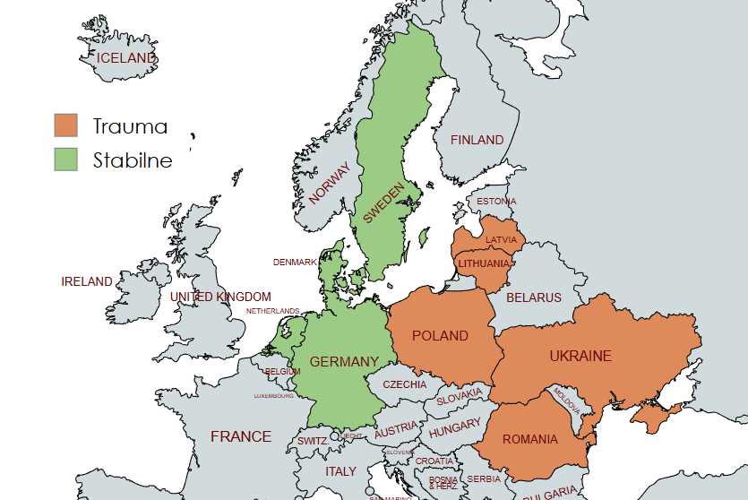

Podział krajów na grupy Trauma i Stabilne

Mapa ilustruje podział na grupy – pomarańczowy kolor dla krajów z doświadczeniem intensywnych kryzysów historycznych, zielony dla krajów o względnej stabilności instytucjonalnej.

# 4 Poziom zaufania społecznego w wybranych krajach

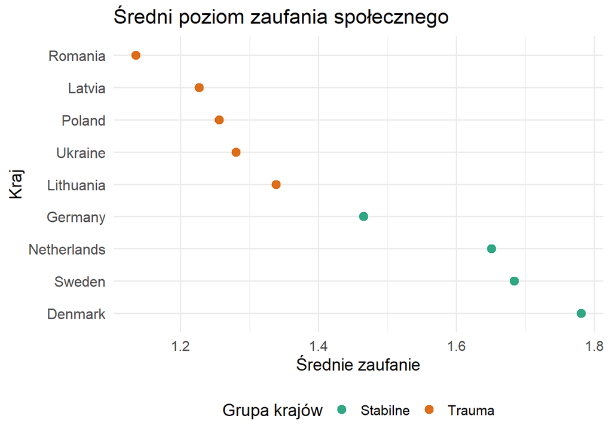

Kraje grupy „Stabilne” (Szwecja, Dania, Niemcy, Holandia) osiągają wyraźnie wyższe wartości. Kraje grupy „Trauma” (Polska, Ukraina, Litwa, Łotwa, Rumunia) tworzą zwartą grupę o znacznie niższym poziomie zaufania.

# 5 Poziom zaufania społecznego

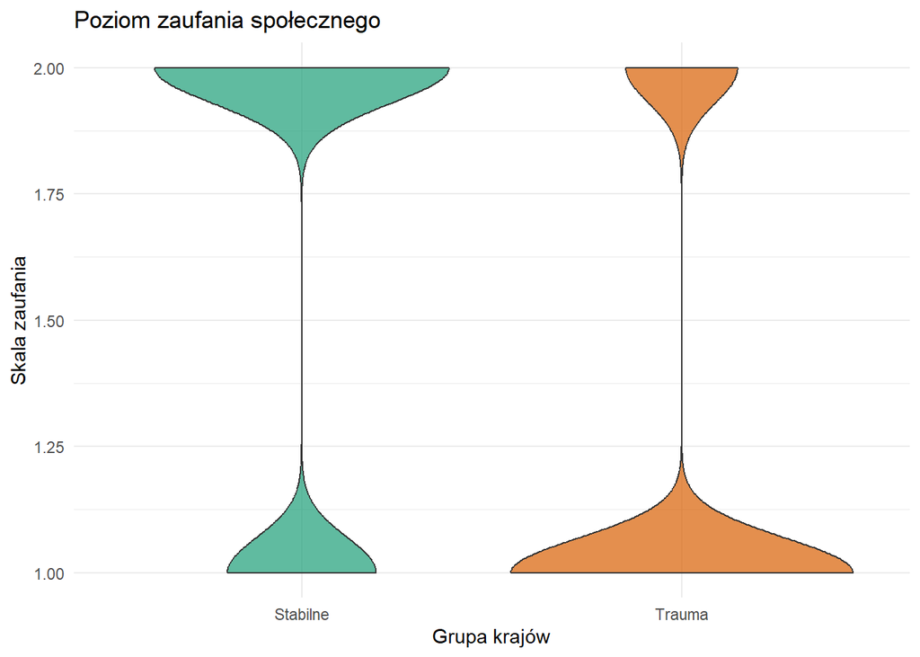

Wykres pokazuje rozkład odpowiedzi na pytanie o zaufanie w obu grupach. W grupie Stabilne większość odpowiedzi koncentruje się w wyższej części skali, podczas gdy w grupie Trauma dominują wartości niskie – widać wyraźne przesunięcie w dół.

# 6 Satysfakcja z życia

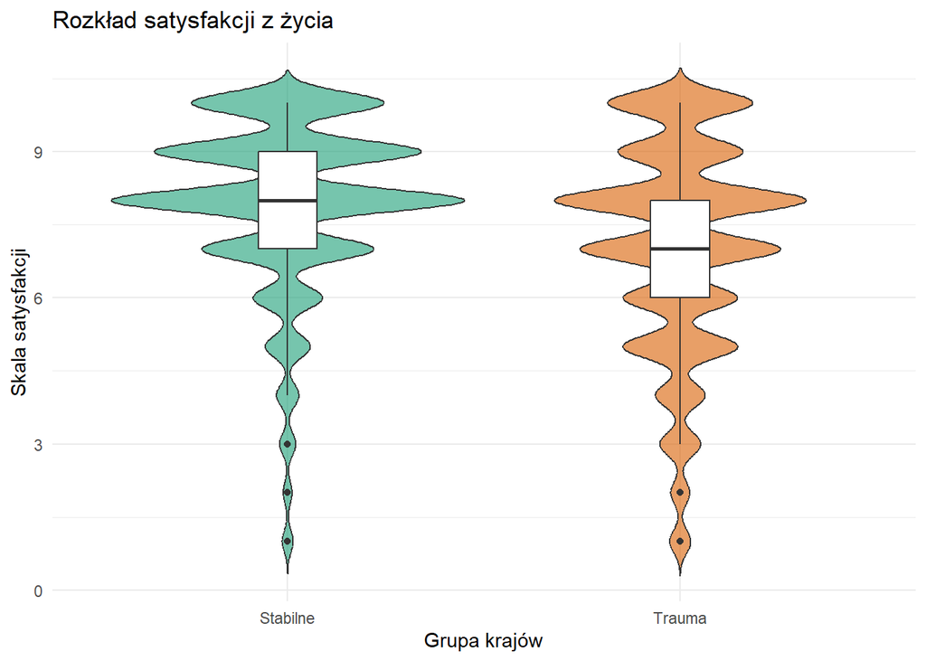

Wykres violin z nałożonym boxplotem pokazuje rozkład satysfakcji z życia w obu grupach. W grupie Stabilne mediana leży wyżej, a najszersza część rozkładu koncentruje się w górnej części skali – powyżej mediany rozkład jest szerszy niż w grupie Trauma. W grupie Trauma mediana jest niższa, a dolna część wyraźnie grubsza.

# 7 Poczucie szczęścia

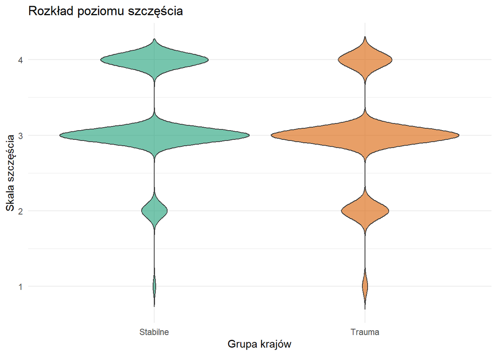

Najszersza część rozkładu w obu grupach przypada na okolice oceny 3. Powyżej trójki znacznie szerszy jest rozkład w grupie Stabilne, natomiast poniżej trójki wyraźnie więcej odpowiedzi ma grupa Trauma.

# 8 Zależność między zaufaniem a poczuciem szczęścia

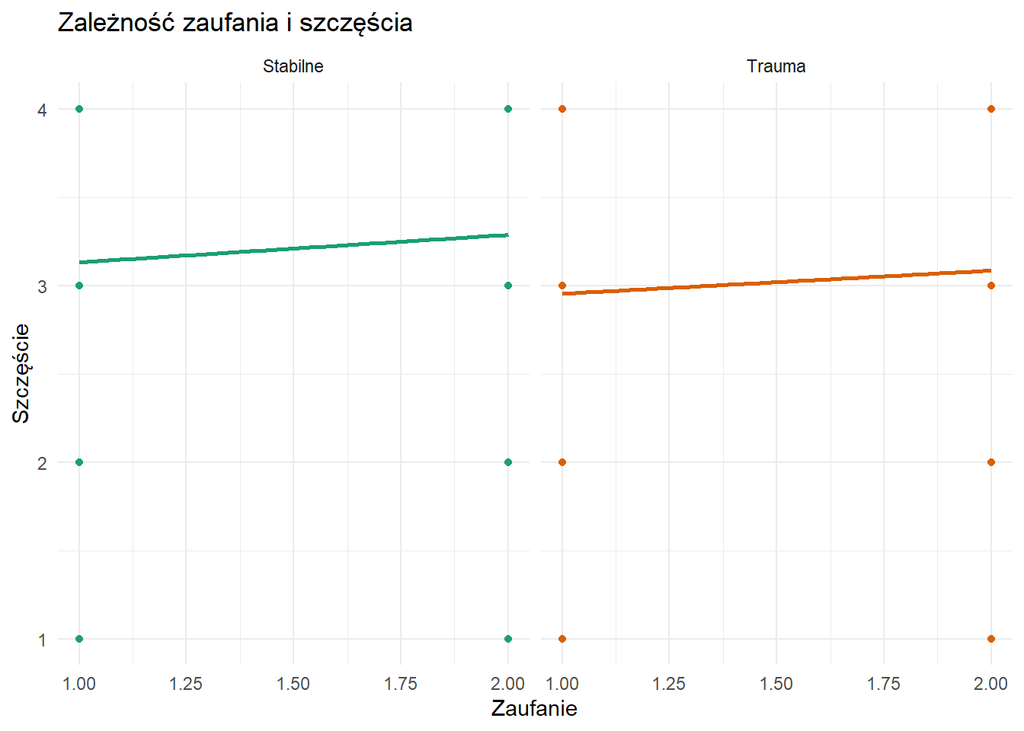

Wykres punktowy z liniami regresji pokazuje relację między zaufaniem a poczuciem szczęścia oddzielnie dla każdej grupy. W obu grupach widoczna jest słaba dodatnia zależność, jednak w grupie Stabilne linia jest nieco bardziej nachylona, a punkty są ogólnie wyżej na osi szczęścia.

# 9 Różnice pokoleniowe w zaufaniu społecznym

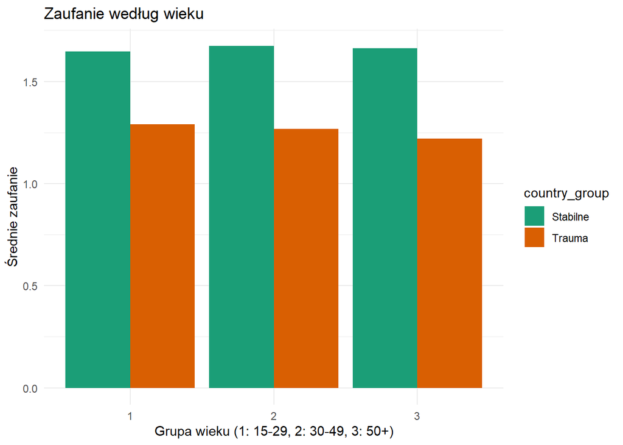

Wykres słupkowy porównuje średnie zaufanie w trzech szerokich grupach wiekowych. W obu grupach krajów poziom zaufania pozostaje stosunkowo stabilny między pokoleniami, a obserwowane różnice są bardzo niewielkie i w dużej mierze trudne do uznania za istotne. W grupie Trauma najmłodsza kategoria ma nieznacznie wyższą średnią niż dwie starsze, ale różnice pozostają niewielkie.

# 10 Zależność zaufania od wieku

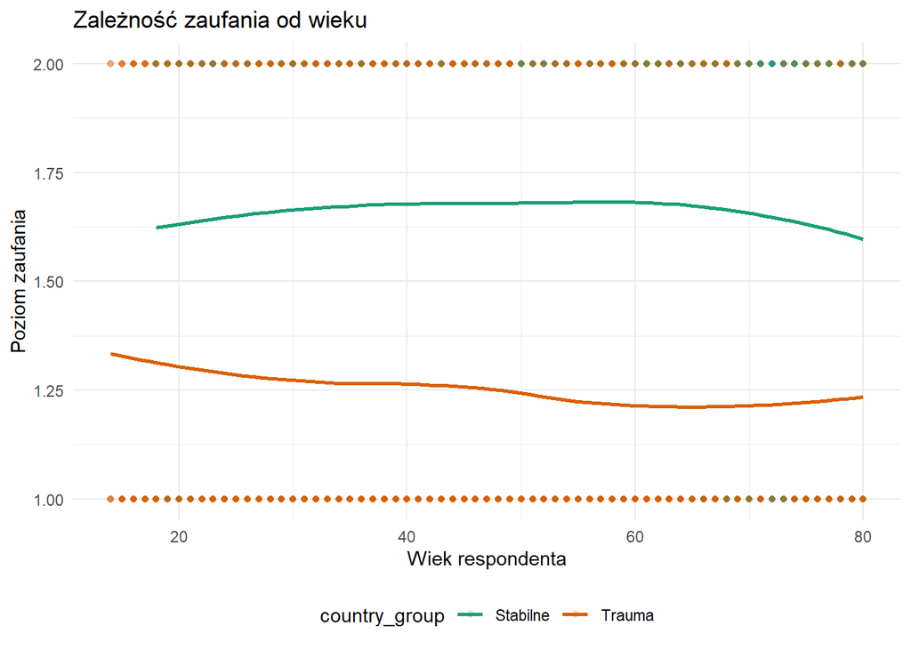

# 11 Podsumowanie i wnioski

Różnice pokoleniowe w zakresie zaufania społecznego okazują się niewielkie w obu grupach krajów. Choć w państwach posttransformacyjnych młodsze kohorty wykazują nieco wyższe zaufanie niż starsze, skala tych różnic nie wskazuje na wyraźny przełom międzypokoleniowy. Wyniki sugerują trwały wpływ doświadczeń historycznych na kapitał społeczny, przy jednoczesnych, bardzo powolnych oznakach zmian w młodszych generacjach.

# 12 Ograniczenia badania

- Uproszczony podział krajów na grupy
- Dane pochodzą z 2017 roku – nie uwzględniają późniejszych wydarzeń
- Analiza ma charakter opisowy – nie pozwala na wnioskowanie o przyczynowości
- Różne daty zbierania danych w poszczególnych krajach

# 13 Bibliografia

European Values Study. 2017. “European Values Study 2017: Integrated Dataset.” GESIS Data Archive. https://search.gesis.org/research_data/ZA7500.